# Predicting Excessive Enforcement Patterns in Police Behavior After Vehicles Stops in New York

Model Selection and Evaluation - Logistic Regression 4-Wheels

Gianmaria Pizzo

These `.Rmd` files represent the project submission for the course [Statistical Inference and Learning](https://www.unive.it/data/course/521944) by Professor [Cristiano Varin](https://www.unive.it/data/people/5592728) at [Ca’ Foscari University of Venice](https://www.unive.it/) for the year 2025/2026.

# 0) Environment

## 0.1) Packages

```r
requirements <- c(
  "scales", "purrr", "broom", "stringr", "dplyr", "tidyr",
  "viridis", "ggplot2", "patchwork", "pROC", "kableExtra",
  "effects", "car"
)
```

Note that some of the packages may not be used, but to avoid any error related to dependencies, we are going to keep all of these libraries. Now, the loading of all packages should be immediate.

## 0.2) Functions

Here we define the helper functions used throughout model selection and evaluation, kept in one place for reuse across every model fitted below.

### 0.2.1) Data-Split Diagnostics

```r
# ==============================================================================
# 1. Train / Test Split Diagnostics
# ==============================================================================

#' @title Check Train/Test Level Proportions
#'
#' @description Tabulates one variable's level proportions separately in
#' `train` and `test` and reports the discrepancy in percentage points. Used
#' to verify that the stratified split preserved the marginal distribution of
#' key covariates.
#'
#' @param var The column name (present in both `train` and `test`) to tabulate.
#' @param label Human-readable label for the variable, stored in the output.
#'
#' @return A tibble with columns variable, level, train, test, diff_ppt.
check_prop <- function(var, label) {
  # Compute the relative frequency of each level in the training set
  tr <- prop.table(table(train[[var]]))
  # Compute the relative frequency of each level in the test set
  te <- prop.table(table(test[[var]]))
  # Create a summary table comparing train and test proportions
  tibble(
    # Variable levels
    level = names(tr),
    # Proportion in training set
    train = as.numeric(tr),
    # Proportion in test set
    test = as.numeric(te),
    # Difference in % between test and training proportions
    diff_ppt = round((as.numeric(te) - as.numeric(tr)) * 100, 2)
  ) %>%
    # Add descriptive variable name
    mutate(variable = label) %>%
    # Move variable name to first column
    relocate(variable)
}
```

### 0.2.2) Threshold and Confusion-Matrix Helpers

```r
# ==============================================================================
# 2. Threshold Selection and Confusion-Matrix Helpers
# ==============================================================================

#' @title Find the Youden-Optimal Classification Threshold
#'
#' @description Finds the probability threshold on an ROC curve that
#' maximises Youden's J statistic (sensitivity + specificity − 1), used
#' throughout as the single decision threshold for turning predicted
#' probabilities into classes.
#'
#' @param roc_obj A pROC "roc" object, as returned by pROC::roc().
#'
#' @return A numeric scalar, the optimal threshold on the probability scale.
best_thresh <- function(roc_obj) {
  pROC::coords(
    roc_obj, "best", ret = "threshold",
    best.method = "youden", quiet = TRUE
  )$threshold
}


#' @title Tally a Confusion Matrix
#'
#' @description Cross-tabulates actual vs predicted binary class labels.
#'
#' @param actual Integer/numeric vector of 0/1 true labels.
#' @param predicted Integer/numeric vector of 0/1 predicted labels.
#'
#' @return A tibble with columns Actual, Predicted, n (one row per non-empty cell).
conf_tib <- function(actual, predicted) {
  tibble(
    Actual = factor(actual, levels = c(0, 1)),
    Predicted = factor(predicted, levels = c(0, 1))
  ) %>%
    count(Actual, Predicted)
}


#' @title Plot a Confusion-Matrix Heatmap
#'
#' @description Renders conf_tib() output as a 2x2 tile plot with cell counts.
#'
#' @param actual Integer/numeric vector of 0/1 true labels.
#' @param predicted Integer/numeric vector of 0/1 predicted labels.
#' @param title Main title of the plot.
#'
#' @return A ggplot2 object.
plot_cm <- function(actual, predicted, title = "Confusion Matrix") {
  conf_tib(actual, predicted) %>%
    ggplot(aes(Predicted, Actual, fill = n)) +
    geom_tile(colour = "white") +
    geom_text(aes(label = scales::comma(n)), size = 5.5, fontface = "bold") +
    scale_fill_gradient(low = "#e8f4f8", high = "#2c7bb6", guide = "none") +
    scale_x_discrete(labels = c("0" = "No arrest", "1" = "Arrest")) +
    scale_y_discrete(labels = c("0" = "No arrest", "1" = "Arrest")) +
    labs(title = title, x = "Predicted", y = "Actual") +
    theme_minimal(base_size = 12) +
    theme(panel.grid = element_blank())
}


#' @title Compute Threshold-Dependent Classification Metrics
#'
#' @description Computes sensitivity, specificity, balanced accuracy, PPV,
#' and NPV for a fixed set of hard class predictions against the true labels.
#'
#' @param actual Integer/numeric vector of 0/1 true labels.
#' @param predicted Integer/numeric vector of 0/1 predicted labels.
#' @param pos Value in `actual`/`predicted` denoting the positive class.
#'
#' @return A named list with sensitivity, specificity, balanced_acc, ppv, npv.
class_metrics <- function(actual, predicted, pos = 1) {
  tp <- as.numeric(sum(actual == pos & predicted == pos))
  tn <- as.numeric(sum(actual != pos & predicted != pos))
  fp <- as.numeric(sum(actual != pos & predicted == pos))
  fn <- as.numeric(sum(actual == pos & predicted != pos))
  sens <- tp / (tp + fn)
  spec <- tn / (tn + fp)
  list(
    sensitivity = sens,
    specificity = spec,
    balanced_acc = (sens + spec) / 2,
    ppv = tp / (tp + fp),
    npv = tn / (tn + fn)
  )
}


# ==============================================================================
# 3. Probability-Based Evaluation Metrics
# ==============================================================================

#' @title Compute the Full Evaluation-Metrics Tibble for One Model
#'
#' @description Given predicted probabilities and true labels, computes
#' threshold-free metrics (AUC, PR-AUC, log-loss, Brier score) plus
#' threshold-dependent metrics at the Youden-optimal cut-off (sensitivity,
#' specificity, precision, F1, MCC, balanced accuracy). Returns one row per
#' call, so results from multiple models can be row-bound into a comparison
#' table.
#'
#' @param actual Integer/numeric vector of 0/1 true labels.
#' @param prob Numeric vector of predicted P(arrested = 1), same length as `actual`.
#' @param thr Classification threshold selected externally (on the training set),
#' applied here rather than recomputed from `actual`/`prob` to avoid leaking test labels.
#' @param model_name Label stored in the Model column.
#'
#' @return A one-row tibble of rounded metrics (see column names in the body).
compute_metrics <- function(actual, prob, thr, model_name = "Model") {
  valid <- !is.na(actual) & !is.na(prob)
  actual <- actual[valid]
  prob <- prob[valid]

  roc_obj <- pROC::roc(actual, prob, quiet = TRUE)
  auc_val <- as.numeric(pROC::auc(roc_obj))
  pred_cl <- as.integer(prob >= thr)

  # Confusion Matrix Metrics
  tp <- as.numeric(sum(actual == 1 & pred_cl == 1))
  tn <- as.numeric(sum(actual == 0 & pred_cl == 0))
  fp <- as.numeric(sum(actual == 0 & pred_cl == 1))
  fn <- as.numeric(sum(actual == 1 & pred_cl == 0))

  # Confusion Matrix Derived Metrics
  sens <- (
    if ((tp+fn) == 0) NA_real_
    else tp / (tp+fn)
  )
  spec <- (
    if ((tn+fp) == 0) NA_real_
    else tn / (tn+fp)
  )
  prec <- (
    if ((tp+fp) == 0) NA_real_
    else tp / (tp+fp)
  )
  f1 <- (
    if (is.na(prec) || is.na(sens) || (prec+sens) == 0) NA_real_
    else 2 * prec * sens / (prec + sens)
  )

  # MCC
  mcc_den <- sqrt(
    as.numeric(tp+fp) * as.numeric(tp+fn) *
    as.numeric(tn+fp) * as.numeric(tn+fn)
  )
  mcc_val <- (
    if (mcc_den == 0) NA_real_
    else (tp*tn - fp*fn) / mcc_den
  )

  # Logloss
  eps <- 1e-15
  logloss <- -mean(
    actual * log(pmax(prob, eps)) +
    (1-actual) * log(pmax(1-prob, eps))
  )

  # Brier Score
  brier <- mean((prob - actual)^2)

  # PR-AUC via trapezoid rule over pROC coords (pROC has no built-in PR-AUC)
  pr_raw <- pROC::coords(
    roc_obj, "all", ret = c("sensitivity", "precision"),
    transpose = FALSE, drop = FALSE
  )

  names(pr_raw)[names(pr_raw) == "sensitivity"] <- "recall"

  pr_raw <- pr_raw %>%
    filter(!is.nan(precision), !is.na(precision), !is.nan(recall)) %>%
    arrange(recall)

  pr_auc_val <- if (nrow(pr_raw) >= 2)
    sum(diff(pr_raw$recall) * (head(pr_raw$precision, -1) + tail(pr_raw$precision, -1)) / 2)
  else NA_real_

  # Print Metrics
  tibble(
    Model = model_name,
    AUC = round(auc_val, 4),
    PR_AUC = round(pr_auc_val, 4),
    Log_Loss = round(logloss, 4),
    Brier = round(brier, 4),
    Threshold = round(thr, 4),
    Sensitivity = round(sens, 3),
    Specificity = round(spec, 3),
    Precision = round(prec, 3),
    F1 = round(f1, 3),
    MCC = round(mcc_val, 3),
    Bal_Acc = round(
      if (!is.na(sens) && !is.na(spec)) (sens+spec)/2
      else NA_real_, 3
    )
  )
}
```

### 0.2.3) Model Evaluation Plot Functions

```r
# ==============================================================================
# 4. Plots for Single-Model Evaluation
# ==============================================================================

#' @title Plot the ROC Curve for a Single Model
#'
#' @description Plots sensitivity vs specificity across all thresholds, with
#' the AUC annotated on the panel.
#'
#' @param actual Integer/numeric vector of 0/1 true labels.
#' @param prob Numeric vector of predicted P(arrested = 1), same length as `actual`.
#' @param title Main title of the plot.
#'
#' @return A ggplot2 object.
plot_roc_single <- function(actual, prob, title = "ROC Curve") {
  roc_obj <- pROC::roc(actual, prob, quiet = TRUE)
  auc_lbl <- paste0("AUC = ", round(as.numeric(pROC::auc(roc_obj)), 4))
  pROC::ggroc(roc_obj, colour = "#2c7bb6", linewidth = 0.9) +
    geom_abline(slope = 1, intercept = 1, linetype = "dashed", colour = "grey60") +
    annotate("text", x = 0.25, y = 0.06, label = auc_lbl, colour = "#2c7bb6", size = 4) +
    labs(x = "Specificity", y = "Sensitivity", title = title) +
    theme_minimal(base_size = 11) + theme(panel.grid.minor = element_blank())
}
```

```r
#' @title Plot the Precision-Recall Curve for a Single Model
#'
#' @description Plots precision vs recall across all thresholds against the
#' no-skill baseline (the class prevalence), with PR-AUC annotated. More
#' informative than the ROC curve under the severe class imbalance here.
#'
#' @param actual Integer/numeric vector of 0/1 true labels.
#' @param prob Numeric vector of predicted P(arrested = 1), same length as `actual`.
#' @param title Main title of the plot.
#'
#' @return A ggplot2 object.
plot_pr_single <- function(actual, prob, title = "Precision-Recall Curve") {
  roc_obj <- pROC::roc(actual, prob, quiet = TRUE)
  pr_raw  <- pROC::coords(roc_obj, "all",
                           ret = c("sensitivity", "precision"),
                           transpose = FALSE, drop = FALSE)
  names(pr_raw)[names(pr_raw) == "sensitivity"] <- "recall"
  pr_df <- pr_raw %>%
    filter(!is.nan(precision), !is.na(precision)) %>% arrange(recall)

  # PR-AUC via trapezoid rule, same approach as in compute_metrics()
  pr_auc_lbl <- if (nrow(pr_df) >= 2) {
    v <- sum(diff(pr_df$recall) *
               (head(pr_df$precision,-1) + tail(pr_df$precision,-1)) / 2)
    paste0("PR-AUC = ", round(v, 4))
  } else "PR-AUC = NA"
  baseline <- mean(actual)
  ggplot(pr_df, aes(x = recall, y = precision)) +
    geom_line(colour = "#d73027", linewidth = 0.9) +
    geom_hline(yintercept = baseline, linetype = "dashed", colour = "grey55") +
    annotate("text", x = 0.02, y = baseline + 0.015,
             label = paste0("No-skill = ", round(baseline, 3)),
             colour = "grey40", size = 3.2, hjust = 0) +
    annotate("text", x = 0.55, y = 0.90, label = pr_auc_lbl,
             colour = "#d73027", size = 4) +
    scale_x_continuous(limits = c(0, 1)) + scale_y_continuous(limits = c(0, 1)) +
    labs(x = "Recall", y = "Precision", title = title) +
    theme_minimal(base_size = 11) + theme(panel.grid.minor = element_blank())
}
```

```r
#' @title Plot the Calibration (Reliability) Curve for a Single Model
#'
#' @description Bins predictions into `n_bins` equal-frequency groups and
#' plots mean predicted probability against observed positive rate per bin,
#' against the perfect-calibration diagonal.
#'
#' @param actual Integer/numeric vector of 0/1 true labels.
#' @param prob Numeric vector of predicted P(arrested = 1), same length as `actual`.
#' @param title Main title of the plot.
#' @param n_bins Number of quantile bins of `prob`.
#'
#' @return A ggplot2 object.
plot_calibration_single <- function(actual, prob, title = "Calibration Plot",
                                    n_bins = 10) {
  # Quantile breaks (not equal-width) so each bin has a comparable sample size
  # despite the predicted probabilities being heavily right-skewed
  brks  <- unique(quantile(prob, seq(0, 1, length.out = n_bins + 1), na.rm = TRUE))
  cal_df <- tibble(actual = actual, prob = prob) %>%
    mutate(bin = cut(prob, breaks = brks, include.lowest = TRUE)) %>%
    filter(!is.na(bin)) %>%
    group_by(bin) %>%
    summarise(mean_pred = mean(prob), mean_obs = mean(actual),
              n = n(), .groups = "drop")
  ggplot(cal_df, aes(x = mean_pred, y = mean_obs)) +
    geom_abline(slope = 1, intercept = 0, linetype = "dashed", colour = "grey55") +
    geom_line(colour = "#2c7bb6", linewidth = 0.8) +
    geom_point(aes(size = n), colour = "#2c7bb6", alpha = 0.85) +
    scale_size_continuous(name = "Count", range = c(2, 9)) +
    scale_x_continuous(labels = scales::percent_format(accuracy = 0.1)) +
    scale_y_continuous(labels = scales::percent_format(accuracy = 0.1)) +
    labs(x = "Mean predicted probability", y = "Observed positive rate",
         title = title,
         caption = "Size ∝ bin count.  Dashed = perfect calibration.") +
    theme_minimal(base_size = 11) +
    theme(legend.position = "bottom", panel.grid.minor = element_blank())
}
```

```r
#' @title Plot the Threshold-Sweep Metrics for a Single Model
#'
#' @description Plots sensitivity, specificity, precision, and F1 as
#' functions of the classification threshold, with the Youden-optimal
#' threshold marked.
#'
#' @param actual Integer/numeric vector of 0/1 true labels.
#' @param prob Numeric vector of predicted P(arrested = 1), same length as `actual`.
#' @param thr Classification threshold selected externally (on the training set).
#' @param title Main title of the plot.
#'
#' @return A ggplot2 object.
plot_threshold_single <- function(actual, prob, thr, title = "Threshold Analysis") {
  roc_obj  <- pROC::roc(actual, prob, quiet = TRUE)
  thr_data <- pROC::coords(roc_obj, "all",
                            ret = c("threshold","sensitivity","specificity","precision"),
                            transpose = FALSE, drop = FALSE) %>%
    filter(is.finite(threshold), threshold >= 0, threshold <= 1) %>%
    mutate(f1 = ifelse(!is.nan(precision) & (precision + sensitivity) > 0,
                       2 * precision * sensitivity / (precision + sensitivity), 0)) %>%
    pivot_longer(c(sensitivity, specificity, precision, f1),
                 names_to = "Metric", values_to = "Value") %>%
    mutate(Metric = dplyr::recode(Metric,
      sensitivity = "Sensitivity", specificity = "Specificity",
      precision   = "Precision",   f1          = "F1 Score"))
  ggplot(thr_data, aes(x = threshold, y = Value, colour = Metric)) +
    geom_line(linewidth = 0.75, na.rm = TRUE) +
    geom_vline(xintercept = thr, linetype = "dashed",
               colour = "grey35", linewidth = 0.55) +
    annotate("text", x = thr, y = 0.04,
             label = paste0("Train-selected\n", round(thr, 3)),
             hjust = -0.08, size = 3, colour = "grey30") +
    scale_colour_viridis_d(option = "turbo", begin = 0.05, end = 0.92) +
    scale_y_continuous(limits = c(0, 1)) +
    labs(x = "Threshold", y = "Metric value", colour = NULL, title = title,
         caption = "Dashed: threshold selected on the training set") +
    theme_minimal(base_size = 11) +
    theme(legend.position = "bottom", panel.grid.minor = element_blank())
}
```

```r
#' @title Plot the 2x2 Evaluation Panel for a Single Model
#'
#' @description Composes plot_roc_single(), plot_pr_single(),
#' plot_calibration_single(), and plot_threshold_single() into one
#' (ROC | PR) / (Calibration | Threshold) patchwork layout.
#'
#' @param actual Integer/numeric vector of 0/1 true labels.
#' @param prob Numeric vector of predicted P(arrested = 1), same length as `actual`.
#' @param thr Classification threshold selected externally (on the training set).
#' @param model_name Prefixed to each sub-plot's title.
#'
#' @return A patchwork object (composed ggplot2 object).
eval_quad_plot <- function(actual, prob, thr, model_name) {
  p1 <- plot_roc_single(actual, prob,   paste(model_name, "— ROC"))
  p2 <- plot_pr_single(actual, prob,    paste(model_name, "— Precision-Recall"))
  p3 <- plot_calibration_single(actual, prob, paste(model_name, "— Calibration"))
  p4 <- plot_threshold_single(actual, prob, thr, paste(model_name, "— Threshold Analysis"))
  (p1 | p2) / (p3 | p4)
}
```

# 1) Data Loading and Preparation

```r
vehstop <- read.csv("data/vehiclestops_4_wheels_final.csv")
```

## 1.1) Factor conversion and Reference Levels

We convert all categorical predictors to factors and set interpretable reference levels before any modelling step, ensuring consistency between all downstream model fits and cross-validation folds.

```r
# Ordered weekday levels (ISO order)
wday_levels <- c("Monday", "Tuesday", "Wednesday", "Thursday", "Friday", "Saturday", "Sunday")

# Ordered time bracket levels
tbkt_levels <- c(
  "Late night (0–3)",
  "Early morning (4–7)",
  "Morning commute (8–11)",
  "Midday (12–15)",
  "Afternoon/evening (16–19)",
  "Night (20–23)"
)

# Ordered age-bracket levels
abkt_levels <- c("Under 18", "18–24", "25–34", "35–44", "45–54", "55–64", "65+", "Unknown")

vehstop <- vehstop %>%
  mutate(
    year = factor(year),
    month = factor(month, levels = 1:12),
    weekday = factor(weekday, levels = wday_levels),
    hour = factor(hour, levels = 0:23),
    time_bracket = factor(time_bracket, levels = tbkt_levels),
    area = factor(area),
    boro = factor(boro),
    sex = factor(sex),
    ethnicity = factor(ethnicity),
    age_bracket = factor(age_bracket, levels = abkt_levels)
  )

# Reference levels chosen for interpretable contrasts
vehstop$sex <- relevel(vehstop$sex, ref = "M")
vehstop$ethnicity <- relevel(vehstop$ethnicity, ref = "White")
vehstop$weekday <- relevel(vehstop$weekday, ref = "Monday")
vehstop$time_bracket <- relevel(vehstop$time_bracket, ref = "Morning commute (8–11)")
vehstop$age_bracket <- relevel(vehstop$age_bracket, ref = "25–34")

rm(wday_levels, tbkt_levels, abkt_levels)
```

## 1.2) Stratified Train / Test Split

For the train/test split, a **stratified sampling approach** is used to ensure that the training and test sets have comparable distributions of the outcome variable (`arrested`) and relevant contextual variables.

This is particularly important because the target variable is imbalanced, with arrested cases representing only a small proportion of all observations. Rather than stratifying only on `arrested`, the code constructs a **joint stratification variable** from `arrested`, `area`, `sex`, `ethnicity`, and `hour` using `interaction()`. Thus, each observation is assigned to a stratum corresponding to a particular combination of these variables.

Formally, the strata can be represented as

$$S_i =
(\text{arrested}_i,\text{area}_i,\text{sex}_i,\text{ethnicity}_i,\text{hour}_i),$$

where $S_i$ denotes the stratum to which observation $i$ belongs. The objective is to sample approximately 80% of observations within each stratum for the training set and retain the remaining 20% for testing:

$$P(i \in \mathcal{D}_{train} \mid S_i=s)
\approx 0.8,
\qquad
P(i \in \mathcal{D}_{test} \mid S_i=s) \approx 0.2.$$

```r
set.seed(2026)

# Joint stratum key; drop = TRUE removes empty combinations
vehstop$.strat <- interaction(
  vehstop$arrested, vehstop$area, vehstop$sex, vehstop$ethnicity, vehstop$hour,
  drop = TRUE
)

train_rows <- vehstop %>%
  dplyr::mutate(.row = row_number()) %>%
  dplyr::group_by(.strat) %>%
  dplyr::slice_sample(prop = 0.8) %>%
  dplyr::pull(.row)

train <- vehstop[ train_rows, ] %>% dplyr::select(-.strat)
test <- vehstop[-train_rows, ] %>% dplyr::select(-.strat)
vehstop <- vehstop %>% dplyr::select(-.strat)
```

In the code, `group_by(.strat) %>% slice_sample(prop = 0.8)` performs this within-stratum sampling, while the observations not selected for training form the test set. This approach aims to preserve not only the overall prevalence of the outcome,

$$P_{\text{train}}(\text{arrested}=1)
\approx P_{\text{test}}(\text{arrested}=1),$$

but also the composition of the data across geographic, demographic, and temporal characteristics. This is desirable because differences in these characteristics could otherwise introduce an unintended distributional difference between the training and test sets. The temporary `.strat` variable is removed after the split because it is used solely to define the sampling groups and is not intended to be used as a predictor in the subsequent modelling.

Finally, the verification code compares the empirical marginal distributions of `arrested`, `area`, `sex`, and `ethnicity` in the two datasets. For a variable $X$ and level $k$, the proportion in each dataset is calculated as

$$\hat{P}_{train}(X=k)
=
\frac{\sum_{i \in \mathcal{D}_{train}} \mathbb{I}(X_i=k)}
{|\mathcal{D}_{train}|},$$

and analogously for the test set. The difference is then reported in **percentage points**:

$$\Delta_k =
100\left[
\hat{P}_{test}(X=k)
-
\hat{P}_{train}(X=k)
\right].$$

Small values of $\Delta_k$ indicate that the corresponding characteristic is similarly represented in the two datasets. The final summary additionally compares the number of observations and the proportion of arrested cases in the training and test sets, providing a direct check that the intended approximately 80/20 split and the class distribution have been maintained.

```r
bind_rows(
  check_prop("arrested", "arrested"),
  check_prop("area", "area"),
  check_prop("sex", "sex"),
  check_prop("ethnicity", "ethnicity")
) %>%
  kbl(
    digits = 4,
    caption = "Proportion of each level in train vs test (diff in percentage points)",
    col.names = c("Variable", "Level", "Train", "Test", "Δ (ppt)")
  ) %>%
  kable_styling(bootstrap_options = c("striped", "hover", "condensed"), full_width = FALSE) %>%
  collapse_rows(columns = 1, valign = "top")
```

Proportion of each level in train vs test (diff in percentage points)

| Variable | Level | Train | Test | Δ (ppt) |
| --- | --- | --- | --- | --- |
| arrested | 0 | 0.9674 | 0.9658 | -0.16 |
|  | 1 | 0.0326 | 0.0342 | 0.16 |
| area | Bronx | 0.1769 | 0.1770 | 0.01 |
|  | Brooklyn | 0.2972 | 0.2968 | -0.04 |
|  | Manhattan | 0.1938 | 0.1938 | 0.00 |
|  | Queens | 0.2550 | 0.2549 | -0.02 |
|  | Staten Island | 0.0771 | 0.0776 | 0.05 |
| sex | M | 0.8098 | 0.8081 | -0.17 |
|  | F | 0.1841 | 0.1849 | 0.08 |
|  | U | 0.0060 | 0.0070 | 0.10 |
| ethnicity | White | 0.1988 | 0.1987 | -0.01 |
|  | Asian / Pacific Islander | 0.1260 | 0.1261 | 0.01 |
|  | Black | 0.3059 | 0.3053 | -0.06 |
|  | Hispanic | 0.2637 | 0.2633 | -0.04 |
|  | Other | 0.0157 | 0.0163 | 0.05 |
|  | Unknown | 0.0899 | 0.0903 | 0.04 |

```r
cat(sprintf(
  "Training set : %d rows  |  Arrested: %.2f%%\nTest set     : %d rows  |  Arrested: %.2f%%\n",
  nrow(train), 100 * mean(train$arrested),
  nrow(test),  100 * mean(test$arrested)
))
```

```
## Training set : 1715002 rows  |  Arrested: 3.26%
## Test set     : 430585 rows  |  Arrested: 3.42%
```

The maximum absolute discrepancy between the two sets is on the order of fractions of a percentage point, confirming that the stratification preserved the joint distribution of the target and the key covariates.

```r
# Remove vehstop for memory purposes
rm(vehstop)
```

# 3) Full Logistic Regression

Here, logistic regression models the conditional probability of belonging to the positive class through the logit transformation,

$$\log\left( \frac{p(X)}{1-p(X)} \right) =
\beta_0 + \beta_1 X_1 + \cdots + \beta_p X_{p}$$

where $p(X)=P(Y=1\mid X)$.

We considered this model for the following reasons

1. First of all, our response `arrested` is **binary** and this makes the binomial logistic model a natural choice for estimating the probability of an arrest.
2. Then we want to exploit its **interpretability**: each coefficient describes the association between a predictor and the log-odds of arrest while holding the other variables fixed. This allows the model to be used not only as a classifier, but also to **investigate** how demographic, time-related and geographic features **are associated with the probability of arrest**.
3. Finally, logistic regression provides a useful **baseline model**. This makes it possible to assess if other models (LASSO, GAM, or Naive Bayes) can be better with respect to predictive power and to analyze the differences in additional complexity.

## 3.1) Assumptions and Setup

We had to exclude `age` as a predictor, since we had missing values that we labeled as `Unknown` in `age_bracket`. Therefore, this is the final formulation of the model

```r
f_final <- arrested ~ year + month + weekday + hour + boro + sex + ethnicity + age_bracket
```

## 3.2) Final Model Fit

```r
mod_logit_best <- glm(f_final, family = binomial, data = train)
```

## 3.3) Specific Analysis and Interpretation

```r
summary(mod_logit_best)
```

```
##
## Call:
## glm(formula = f_final, family = binomial, data = train)
##
## Coefficients:
##                                    Estimate Std. Error  z value Pr(>|z|)
## (Intercept)                       -3.382604   0.032010 -105.673  < 2e-16 ***
## year2024                           0.157845   0.011405   13.840  < 2e-16 ***
## year2025                           0.136686   0.011294   12.102  < 2e-16 ***
## month2                            -0.096468   0.019669   -4.905 9.36e-07 ***
## month3                            -0.084530   0.019522   -4.330 1.49e-05 ***
## month4                            -0.116212   0.020217   -5.748 9.02e-09 ***
## month5                            -0.183589   0.020219   -9.080  < 2e-16 ***
## month6                            -0.158032   0.021055   -7.506 6.11e-14 ***
## month7                            -0.217825   0.021364  -10.196  < 2e-16 ***
## month8                            -0.209462   0.020982   -9.983  < 2e-16 ***
## month9                            -0.178360   0.021301   -8.373  < 2e-16 ***
## month10                           -0.130655   0.020181   -6.474 9.53e-11 ***
## month11                           -0.135749   0.020261   -6.700 2.08e-11 ***
## month12                           -0.031577   0.020373   -1.550 0.121158
## weekdayTuesday                     0.073588   0.017921    4.106 4.02e-05 ***
## weekdayWednesday                   0.074838   0.017555    4.263 2.02e-05 ***
## weekdayThursday                    0.046923   0.017680    2.654 0.007953 **
## weekdayFriday                      0.037793   0.017840    2.118 0.034137 *
## weekdaySaturday                    0.038845   0.018170    2.138 0.032527 *
## weekdaySunday                      0.008041   0.019024    0.423 0.672547
## hour1                              0.034051   0.023645    1.440 0.149829
## hour2                              0.071544   0.027106    2.639 0.008304 **
## hour3                              0.124329   0.032094    3.874 0.000107 ***
## hour4                             -0.060764   0.040612   -1.496 0.134603
## hour5                             -0.956951   0.061432  -15.577  < 2e-16 ***
## hour6                             -1.544611   0.072758  -21.230  < 2e-16 ***
## hour7                             -1.832305   0.064069  -28.599  < 2e-16 ***
## hour8                             -1.553272   0.043534  -35.680  < 2e-16 ***
## hour9                             -1.484004   0.041312  -35.922  < 2e-16 ***
## hour10                            -1.393694   0.042161  -33.056  < 2e-16 ***
## hour11                            -0.943578   0.035758  -26.388  < 2e-16 ***
## hour12                            -0.620465   0.032745  -18.949  < 2e-16 ***
## hour13                            -0.378799   0.030962  -12.234  < 2e-16 ***
## hour14                            -0.309103   0.029601  -10.442  < 2e-16 ***
```

[output cut: 25 more lines]

```
## age_bracket35–44                  -0.244815   0.011617  -21.074  < 2e-16 ***
## age_bracket45–54                  -0.590539   0.015947  -37.031  < 2e-16 ***
## age_bracket55–64                  -1.048189   0.023564  -44.484  < 2e-16 ***
## age_bracket65+                    -1.605060   0.049636  -32.337  < 2e-16 ***
## age_bracketUnknown                -0.835743   0.025137  -33.248  < 2e-16 ***
## ---
## Signif. codes:  0 '***' 0.001 '**' 0.01 '*' 0.05 '.' 0.1 ' ' 1
##
## (Dispersion parameter for binomial family taken to be 1)
##
##     Null deviance: 492405  on 1715001  degrees of freedom
## Residual deviance: 446809  on 1714938  degrees of freedom
## AIC: 446937
##
## Number of Fisher Scoring iterations: 7
```

The model improves the fit compared with the intercept-only model. The **null deviance** decreases from $492,405$ to a **residual deviance** of $446,809$, corresponding to a reduction of $45,596$ deviance units with $63$ additional parameters.

Even though this suggests that our predictors contribute to explaining the probability of arrest, the residual deviance remains relatively large. Unfortunately, this means that a considerable amount of variation is still not captured by the model.

This is what we expected given that the model is simple and has an additive form (we do not consider interactions or non-linear effects here for interpretability).

### 3.3.1) Coefficients analysis

The coefficients are estimated by maximum likelihood and describe changes in the log-odds of the positive outcome/arrests (`arrested = 1`) while holding the remaining predictors fixed.

When several predictors are **categorical**, each factor with $K$ levels is represented through $K-1$ indicator variables relative to a chosen reference category. In this case, the estimated coefficients represent changes in the **log-odds of arrest**, relative to the corresponding reference category and conditional on all other predictors being held fixed.

The intercept ($-3.383$) represents the estimated **log-odds of arrest for an observation belonging to all reference categories** of the categorical predictors (see section 1.1). This corresponds to a baseline arrest probability of approximately **3.3%**. The intercept is strongly statistically significant ($p<2\times10^{-16}$).

Overall, the largest coefficient differences are associated with `hour`, `ethnicity`, `sex`, and `age_bracket`, while `month` and `weekday` generally show smaller conditional differences. Given the very large sample size, many relatively small coefficients are statistically significant, so the **magnitude and direction of the estimates are more informative than significance alone**.

Let us now consider the predictors separately.

#### 3.3.1.1) Time-related

First of all, we consider the time-related predictors:

- `year`: Both **2024** ($0.158$) and **2025** ($0.137$) have positive and highly significant coefficients relative to 2023. Conditional on the remaining predictors, both years are therefore associated with **higher log-odds of arrest than 2023**, with the difference slightly larger in 2024.
- `month`: Monthly coefficients are predominantly negative relative to January. The largest negative differences are observed in **July** ($-0.218$), **August** ($-0.209$), and **May** ($-0.184$). February through November are all significantly below January, although the magnitudes are generally moderate. **December** ($-0.032$) is the only month that does not differ significantly from January ($p=0.121$).
- `weekday`: Weekday effects are relatively small. **Tuesday** ($0.074$), **Wednesday** ($0.075$), and **Thursday** ($0.047$) show small but statistically significant positive differences relative to Monday. Friday ($0.038$) and Saturday ($0.039$) are also positive but of limited magnitude. **Sunday** ($0.008$) is essentially indistinguishable from Monday and is not statistically significant.
- `hour`: The clearest temporal pattern is again associated with **hour of the day**. Relative to midnight, the early-night coefficients are close to zero or slightly positive, with **03:00** reaching $0.124$. From 05:00 onward, however, the coefficients become sharply negative, reaching their minimum at **07:00** ($-1.832$). Large negative estimates persist through the morning, including 06:00 ($-1.545$), 08:00 ($-1.553$), 09:00 ($-1.484$), and 10:00 ($-1.394$). The magnitude then progressively decreases during the afternoon, approaching zero again in the evening. This indicates a pronounced **non-linear time-of-day pattern** that cannot be adequately described by a simple linear effect.

#### 3.3.1.2) Borough

Then we look at `boro` for the geographic coefficients.

- **All borough coefficients are negative and statistically significant relative to the Bronx**, indicating lower conditional log-odds of arrest across all other borough groups after controlling for the remaining predictors.
- The largest differences are observed for **Manhattan South** ($-0.591$) and **Queens North** ($-0.584$), followed by **Queens South** ($-0.382$) and **Brooklyn North** ($-0.253$).
- Smaller negative differences are observed for Manhattan North ($-0.121$), Staten Island ($-0.099$), and Brooklyn South ($-0.080$).

The variation across boroughs indicates that geography still contributes meaningful conditional information to arrest outcomes, although the differences are less extreme than those observed for some temporal, demographic, and ethnicity-related coefficients.

#### 3.3.1.3) Sex

For what concerns `sex`:

- The coefficient for **Female** is strongly negative ($-0.896$) and highly statistically significant relative to males. This indicates substantially lower conditional log-odds of arrest for females after adjusting for all other predictors.
- In contrast, **Unknown sex** has a positive coefficient ($0.183$). The estimate is statistically significant only at the 5% level ($p=0.031$) and has a considerably larger standard error ($0.084$) than the Female coefficient. Its effect should therefore be interpreted more cautiously.

#### 3.3.1.4) Ethnicity

The `ethnicity` coefficients show some of the largest conditional differences in the model relative to the reference ethnicity category.

- **Black** ($1.231$) and **Hispanic** ($1.181$) have large positive and highly statistically significant coefficients. These are among the largest positive estimates in the entire model.
- **Asian / Pacific Islander** also has a positive coefficient ($0.156$), although its magnitude is much smaller.
- In contrast, **Other** ($-0.420$) and **Unknown** ($-0.436$) have statistically significant negative coefficients.

The estimates therefore indicate substantial heterogeneity across ethnicity categories even after adjustment for time, borough, sex, and age. These coefficients should be interpreted as **conditional associations rather than causal effects**, particularly because ethnicity may also capture differences related to geography, policing practices, stop circumstances, and other variables not included in the model.

#### 3.3.1.5) Age Bracket

Finally, for `age_bracket`, using ages **25–34 as the reference category**:

- All estimated age coefficients are negative and statistically significant.
- The smallest differences are observed for ages **18–24** ($-0.133$) and **35–44** ($-0.245$), while individuals **under 18** have a coefficient of $-0.280$.
- The negative effect becomes progressively stronger for older age groups: **45–54** has a coefficient of $-0.591$, **55–64** reaches $-1.048$, and **65+** has the largest age-related coefficient in absolute magnitude at $-1.605$.
- The `Unknown` age category also has a relatively large negative coefficient ($-0.836$).

Overall, the estimates suggest a clear age gradient: relative to the 25–34 reference group, the conditional log-odds of arrest become increasingly lower among older individuals, particularly from age 45 onward.

### 3.3.2) Odd Ratios, Significance and Effects

In logistic regression, coefficients are estimated on the **log-odds scale**, which can be difficult to interpret directly. Thus, they are often transformed into **odds ratios**

$$OR=e^{\beta}$$

For a categorical predictor, the odds ratio **compares the odds of arrest for a given category with those of its reference category, while holding all other predictors fixed**. We say that

- $OR>1$ indicates higher odds of arrest, relative to the reference group (while holding all other predictors fixed);
- $OR<1$ indicates lower odds, relative to the reference group (while holding all other predictors fixed);
- $OR=1$ indicates no difference, relative to the reference group (while holding all other predictors fixed).

```r
predictors <- c("year", "month", "weekday", "hour", "boro", "sex", "ethnicity", "age_bracket")

or_tbl <- tidy(mod_logit_best, conf.int = FALSE, exponentiate = FALSE) %>%
  filter(term != "(Intercept)") %>%
  mutate(
    conf.low = exp(estimate - qnorm(0.975) * std.error),
    conf.high = exp(estimate + qnorm(0.975) * std.error),
    estimate = exp(estimate),
    group = purrr::map_chr(term, function(t) {
      g <- predictors[purrr::map_lgl(predictors, ~ startsWith(t, .x))]
      if (length(g) == 0) "Other" else g[which.max(nchar(g))]
    }),
    level = purrr::map2_chr(term, group, ~ sub(paste0("^", .y), "", .x)),
    sig = case_when(
      p.value < 0.001 ~ "***",
      p.value < 0.01 ~ "**",
      p.value < 0.05 ~ "*",
      p.value < 0.1 ~ ".",
      TRUE ~ ""
    )
  ) %>%
  select(group, level, estimate, conf.low, conf.high, p.value, sig)

or_tbl %>%
  kbl(
    digits = 3,
    caption = "Odds ratios with 95% CI and significance (reference levels: year=2023, month=Jan, weekday=Mon, hour=0, boro=Bronx, sex=M, ethnicity=White, age_bracket=25-34)",
    col.names = c("Group", "Level vs Reference", "OR", "CI 2.5%", "CI 97.5%", "p-value", "")
  ) %>%
  kable_styling(bootstrap_options = c("striped", "hover", "condensed"), full_width = FALSE) %>%
  collapse_rows(columns = 1, valign = "top")
```

Odds ratios with 95% CI and significance (reference levels: year=2023, month=Jan, weekday=Mon, hour=0, boro=Bronx, sex=M, ethnicity=White, age_bracket=25-34)

Group

Level vs Reference

OR

CI 2.5%

CI 97.5%

p-value

year

2024

1.171

1.145

1.197

0.000

***

2025

1.146

1.121

1.172

0.000

***

month

2

0.908

0.874

0.944

0.000

***

3

0.919

0.884

0.955

0.000

***

4

0.890

0.856

0.926

0.000

***

5

0.832

0.800

0.866

0.000

***

6

0.854

0.819

0.890

0.000

***

7

0.804

0.771

0.839

0.000

***

8

0.811

0.778

0.845

0.000

***

9

0.837

0.802

0.872

0.000

***

10

0.878

0.843

0.913

0.000

***

11

0.873

0.839

0.908

0.000

***

12

0.969

0.931

1.008

0.121

weekday

Tuesday

1.076

1.039

1.115

0.000

***

Wednesday

1.078

1.041

1.115

0.000

***

Thursday

1.048

1.012

1.085

0.008

Friday

1.039

1.003

1.075

0.034

Saturday

1.040

1.003

1.077

0.033

Sunday

1.008

0.971

1.046

0.673

hour

1

1.035

0.988

1.084

0.150

2

1.074

1.019

1.133

0.008

3

1.132

1.063

1.206

0.000

***

4

0.941

0.869

1.019

0.135

5

0.384

0.340

0.433

0.000

***

6

0.213

0.185

0.246

0.000

***

7

0.160

0.141

0.181

0.000

***

8

0.212

0.194

0.230

0.000

***

9

0.227

0.209

0.246

0.000

***

10

0.248

0.228

0.270

0.000

***

11

0.389

0.363

0.417

0.000

***

12

0.538

0.504

0.573

0.000

***

13

0.685

0.644

0.728

0.000

***

14

0.734

0.693

0.778

0.000

***

15

0.681

0.644

0.719

0.000

***

16

0.668

0.637

0.701

0.000

***

17

0.735

0.702

0.771

0.000

***

18

0.860

0.823

0.900

0.000

***

19

1.052

1.009

1.097

0.018

20

1.026

0.984

1.070

0.235

21

1.013

0.971

1.057

0.551

22

1.026

0.983

1.071

0.238

23

0.983

0.939

1.028

0.449

boro

Brooklyn (North)

0.777

0.754

0.800

0.000

***

Brooklyn (South)

0.923

0.898

0.948

0.000

***

Manhattan (North)

0.886

0.860

0.913

0.000

***

Manhattan (South)

0.554

0.530

0.579

0.000

***

Queens (North)

0.558

0.539

0.577

0.000

***

Queens (South)

0.682

0.661

0.704

0.000

***

Staten Island

0.906

0.872

0.940

0.000

***

sex

F

0.408

0.396

0.421

0.000

***

U

1.200

1.017

1.416

0.031

ethnicity

Asian / Pacific Islander

1.169

1.115

1.227

0.000

***

Black

3.425

3.307

3.548

0.000

***

Hispanic

3.258

3.142

3.378

0.000

***

Other

0.657

0.577

0.749

0.000

***

Unknown

0.647

0.607

0.689

0.000

***

age_bracket

Under 18

0.756

0.663

0.862

0.000

***

18–24

0.876

0.856

0.897

0.000

***

35–44

0.783

0.765

0.801

0.000

***

45–54

0.554

0.537

0.572

0.000

***

55–64

0.351

0.335

0.367

0.000

***

65+

0.201

0.182

0.221

0.000

***

Unknown

0.434

0.413

0.455

0.000

***

Since this is not easy to visualize, we use the below to display estimated odds ratios with 95% confidence intervals, faceted by predictor

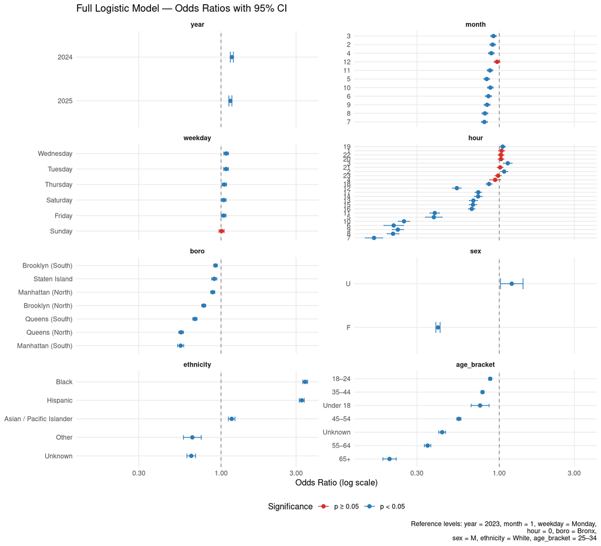

```r
or_plot_data <- or_tbl %>%
  mutate(
    is_sig = p.value < 0.05,
    level = stringr::str_wrap(level, width = 28),
    group = factor(
      group,
      levels = c(
        "year", "month", "weekday", "hour",
        "boro", "sex", "ethnicity", "age_bracket"
      )
    )
  )

ggplot(
  or_plot_data,
  aes(x = estimate, y = reorder(level, estimate), colour = is_sig)
) +
  geom_vline(xintercept = 1, linetype = "dashed", colour = "grey55", linewidth = 0.5) +
  geom_errorbarh(aes(xmin = conf.low, xmax = conf.high), height = 0.25, linewidth = 0.45) +
  geom_point(size = 2) +
  scale_x_log10(labels = scales::number_format(accuracy = 0.01)) +
  scale_colour_manual(
    values = c("TRUE" = "#2c7bb6", "FALSE" = "#d73027"),
    labels = c("TRUE" = "p < 0.05", "FALSE" = "p ≥ 0.05")
  ) +
  facet_wrap(~ group, scales = "free_y", ncol = 2) +
  labs(
    x = "Odds Ratio (log scale)",
    y = NULL,
    colour = "Significance",
    title = "Full Logistic Model — Odds Ratios with 95% CI",
    caption = paste0(
      "Reference levels: year = 2023, month = 1, weekday = Monday,\n",
      "hour = 0, boro = Bronx,\n",
      "sex = M, ethnicity = White, age_bracket = 25–34"
    )
  ) +
  theme_minimal(base_size = 11) +
  theme(
    strip.text = element_text(face = "bold"),
    legend.position = "bottom",
    panel.grid.minor = element_blank()
  )
```

#### 3.3.2.1) Year

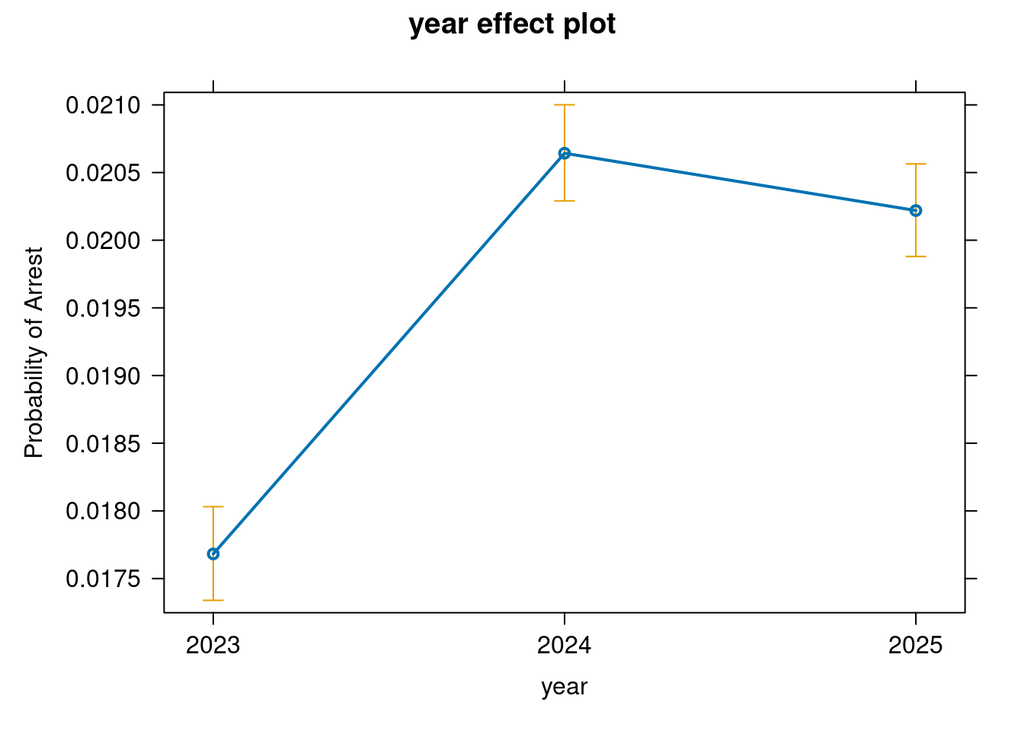

```r
plot(effect("year", mod_logit_best), rescale.axis=FALSE, ylab="Probability of Arrest")
```

Using **2023 as the reference year**, both 2024 and 2025 show statistically significant and higher odds of arrest.

- In 2024, the estimated odds are approximately **17% higher** than in 2023 (OR = 1.171, 95% CI: 1.145–1.197).
- In 2025, they are approximately **15% higher** (OR = 1.146, 95% CI: 1.121–1.172).

#### 3.3.2.2) Month

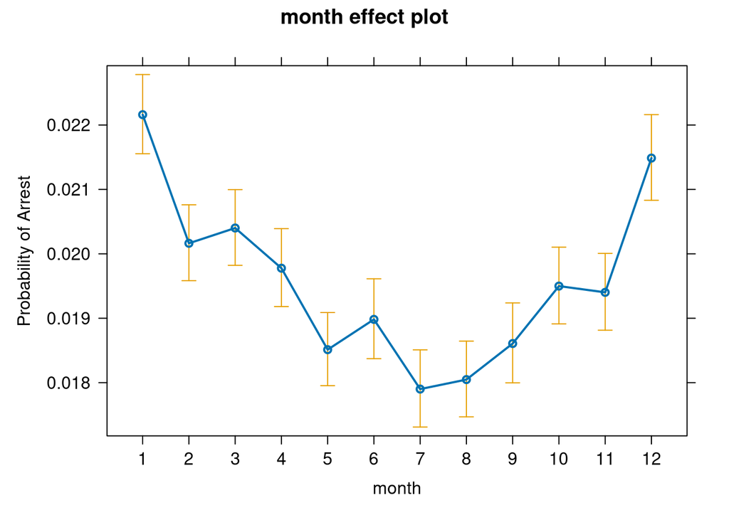

```r
plot(effect("month", mod_logit_best), rescale.axis=FALSE, ylab="Probability of Arrest")
```

The reference category for month is **January**. Most monthly differences are moderate compared with those observed for `hour`, `ethnicity`, or `age_bracket`.

Almost all months show **significantly lower odds of arrest than January**:

- February (OR = 0.908), corresponding to about **9% lower odds**;
- March (OR = 0.919), about **8% lower**;
- April (OR = 0.890), about **11% lower**;
- May (OR = 0.832), about **17% lower**;
- June (OR = 0.854), about **15% lower**;
- July (OR = 0.804), about **20% lower**;
- August (OR = 0.811), about **19% lower**;
- September (OR = 0.837), about **16% lower**;
- October (OR = 0.878), about **12% lower**;
- November (OR = 0.873), about **13% lower**.

The strongest difference is observed in **July**, followed closely by August.

**December** is different: its OR is 0.969, with a 95% confidence interval of 0.931–1.008 and $p=0.121$. Therefore, there is **no statistically significant evidence of a difference between December and January**.

#### 3.3.2.3) Weekday

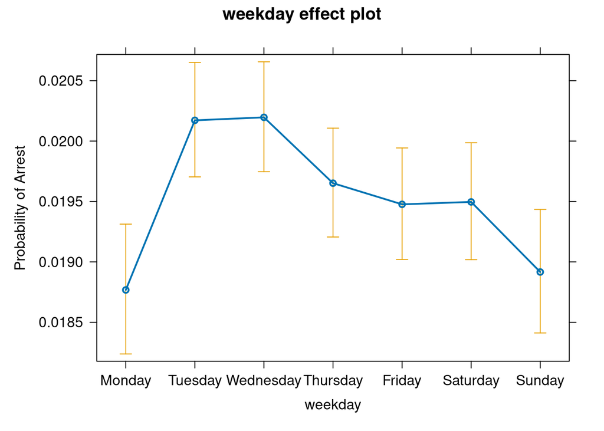

```r
plot(effect("weekday", mod_logit_best), rescale.axis=FALSE, ylab="Probability of Arrest")
```

Using **Monday as the reference category**, weekday differences are generally small.

- Tuesday has an OR of 1.076, corresponding to approximately **8% higher odds** than Monday.
- Wednesday is very similar (OR = 1.078), also corresponding to approximately **8% higher odds**.
- Thursday has an OR of 1.048, corresponding to about **5% higher odds**.
- Friday (OR = 1.039) and Saturday (OR = 1.040) are associated with only around **4% higher odds** than Monday.

All of these differences are statistically significant, although their magnitudes are relatively small.

**Sunday** has an OR of 1.008, with a confidence interval that includes 1 and $p=0.673$. Therefore, there is essentially **no evidence of a difference between Sunday and Monday** after adjustment for the other predictors.

#### 3.3.2.4) Hour

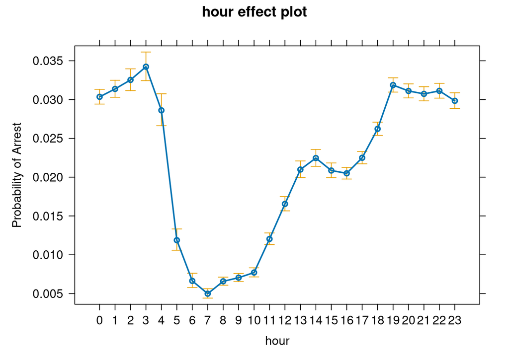

```r
plot(effect("hour", mod_logit_best), rescale.axis=FALSE, ylab="Probability of Arrest")
```

The reference hour is **00:00**, and `hour` again shows one of the strongest and clearest patterns in the model.

- At **01:00**, the OR is 1.035 and is not statistically significant, suggesting little evidence of a difference from midnight.
- At **02:00** (OR = 1.074) and **03:00** (OR = 1.132), the odds are slightly higher than at midnight. At 03:00, this corresponds to approximately **13% higher odds**.
- At **04:00**, the OR decreases to 0.941, but the difference is not statistically significant.

From 05:00 onward, however, there is a **very sharp decline**:

- At 05:00, OR = 0.384, corresponding to approximately **62% lower odds** than at midnight.
- At 06:00, OR = 0.213, or approximately **79% lower odds**.
- The minimum is observed at **07:00**, where OR = 0.160. Conditional on the remaining variables, the odds of arrest at 07:00 are therefore approximately **84% lower than at midnight**.
- Very low odds persist at 08:00 (OR = 0.212), 09:00 (OR = 0.227), and 10:00 (OR = 0.248).

From late morning onward, the odds progressively recover:

- 11:00: OR = 0.389;
- 12:00: OR = 0.538;
- 13:00: OR = 0.685;
- 14:00: OR = 0.734.

The odds remain below the midnight reference during most of the afternoon, although the differences gradually become smaller.

At **19:00**, the OR becomes slightly greater than 1 (OR = 1.052), corresponding to approximately **5% higher odds**, and the difference is statistically significant at the 5% level.

From 20:00 onward, however, the ORs are again very close to 1 and are not statistically significant.

Overall, this confirms a pronounced **non-linear daily pattern**: arrest odds are relatively similar to midnight during the early night, fall dramatically during the morning, and then progressively return toward the midnight level during the afternoon and evening.

#### 3.3.2.5) Borough

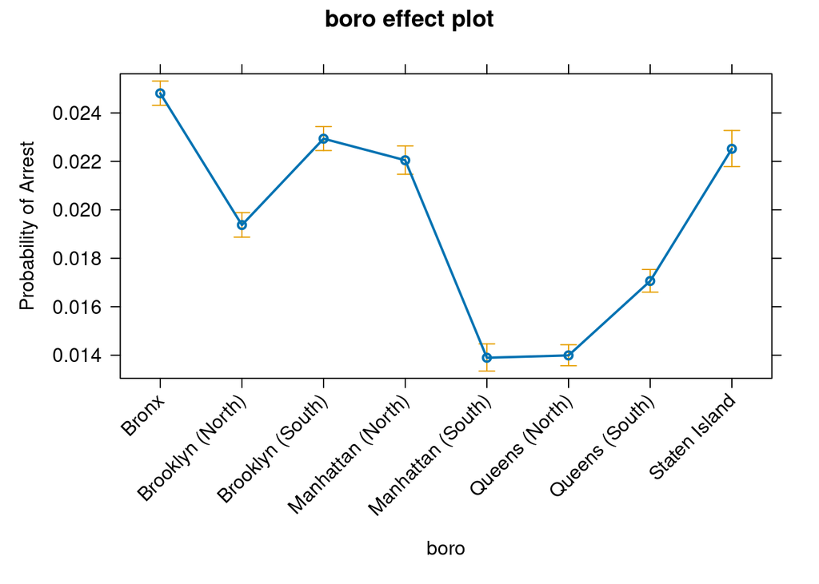

```r
plot(effect("boro", mod_logit_best), rescale.axis=FALSE, ylab="Probability of Arrest", rotx = 45)
```

The **Bronx is the reference category**, and every other borough has an odds ratio significantly below 1.

- **Manhattan South** has an OR of 0.554, corresponding to approximately **45% lower odds of arrest** than the Bronx.
- **Queens North** shows a very similar difference (OR = 0.558), corresponding to approximately **44% lower odds**.
- Queens South has an OR of 0.682, or around **32% lower odds**.
- Brooklyn North has an OR of 0.777, corresponding to approximately **22% lower odds**.

The remaining differences are smaller:

- Manhattan North: OR = 0.886;
- Staten Island: OR = 0.906;
- Brooklyn South: OR = 0.923.

Thus, after adjusting for the other predictors, the Bronx is associated with higher conditional odds of arrest than all the other borough categories, with the largest differences observed for **Manhattan South and Queens North**.

#### 3.3.2.6) Sex

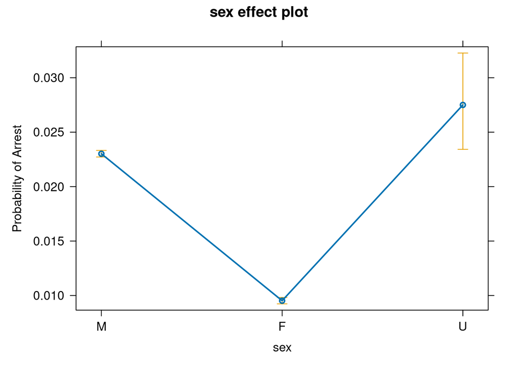

```r
plot(effect("sex", mod_logit_best), rescale.axis=FALSE, ylab="Probability of Arrest")
```

With **Male as the reference category**, the estimated OR for females is 0.408 and is highly statistically significant.

This corresponds to approximately **59% lower conditional odds of arrest for females than males**, after fixing the remaining predictors.

The `Unknown` category instead has an OR of 1.200. This corresponds to approximately **20% higher estimated odds** than the Male reference category. However, the confidence interval is relatively wide (1.017–1.416), and the result is only marginally significant ($p=0.031$). Therefore, this estimate should be interpreted more cautiously.

#### 3.3.2.7) Ethnicity

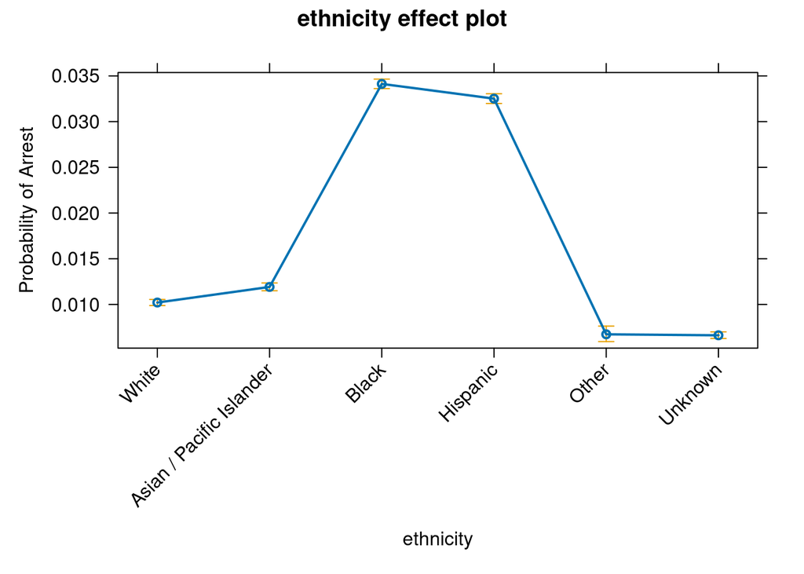

```r
plot(effect("ethnicity", mod_logit_best), rescale.axis=FALSE, ylab="Probability of Arrest", rotx = 45)
```

Using **White as the reference category**, `ethnicity` shows some of the largest differences in the fitted model, and all category effects are statistically significant.

- **Black** observations have an OR of 3.425. Conditional on the remaining predictors, their estimated odds of arrest are therefore approximately **3.4 times those of the White reference category**, or about **243% higher**.
- **Hispanic** observations have a similarly large OR of 3.258, corresponding to approximately **226% higher odds** than the White reference group.
- **Asian / Pacific Islander** has a much more moderate OR of 1.169, corresponding to approximately **17% higher odds**.

On the other hand:

- `Other` has an OR of 0.657, corresponding to approximately **34% lower odds** than White observations;
- `Unknown` has an OR of 0.647, corresponding to approximately **35% lower odds**.

The particularly large ORs for Black and Hispanic observations indicate strong conditional associations in this model. However, they should **not be interpreted causally**: these differences are conditional associations and may also reflect omitted contextual factors, policing practices, stop characteristics, or other sources of heterogeneity not represented in the model.

#### 3.3.2.8) Age bracket

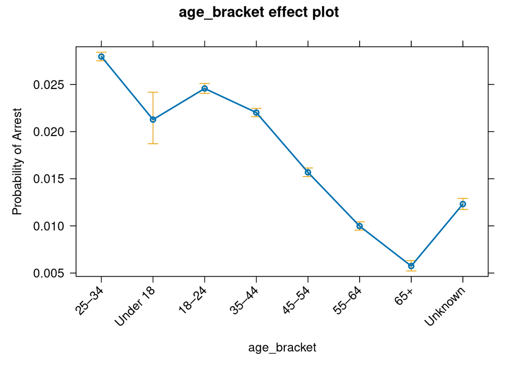

```r
plot(effect("age_bracket", mod_logit_best), rescale.axis=FALSE, ylab="Probability of Arrest", rotx = 45)
```

The reference age category is **25–34 years**, and all other age categories have significantly lower estimated odds of arrest.

- The **Under 18** category has an OR of 0.756, corresponding to approximately **24% lower odds** than the 25–34 reference group.
- Ages **18–24** have an OR of 0.876, corresponding to approximately **12% lower odds**.
- Ages **35–44** have an OR of 0.783, corresponding to approximately **22% lower odds**.

The reduction becomes much stronger in the older age groups:

- Ages **45–54** have an OR of 0.554, corresponding to approximately **45% lower odds**;
- Ages **55–64** have an OR of 0.351, corresponding to approximately **65% lower odds**;
- The **65+** group has the smallest OR, at 0.201. This means that its estimated odds of arrest are approximately **80% lower than those of the 25–34 reference group**, after adjusting for the remaining predictors.

The `Unknown` age category also has substantially lower estimated odds (OR = 0.434), corresponding to approximately **57% lower odds**.

Overall, the ORs reveal a clear age pattern: the **25–34 category has the highest conditional odds among the modeled age groups**, and the odds progressively decline for older individuals, particularly after age 45.

## 3.4) Evaluation on Test Set

```r
# Select threshold on training data
prob_logit_train <- predict(mod_logit_best, newdata = train, type = "response")
roc_logit_train <- pROC::roc(train$arrested, prob_logit_train, quiet = TRUE)
thr_logit <- best_thresh(roc_logit_train)

prob_logit <- predict(mod_logit_best, newdata = test, type = "response")
roc_logit <- pROC::roc(test$arrested, prob_logit, quiet = TRUE)
auc_logit <- as.numeric(pROC::auc(roc_logit))
class_logit <- as.integer(prob_logit >= thr_logit)
met_logit <- class_metrics(test$arrested, class_logit)
```

### 3.4.1) Confusion Matrix

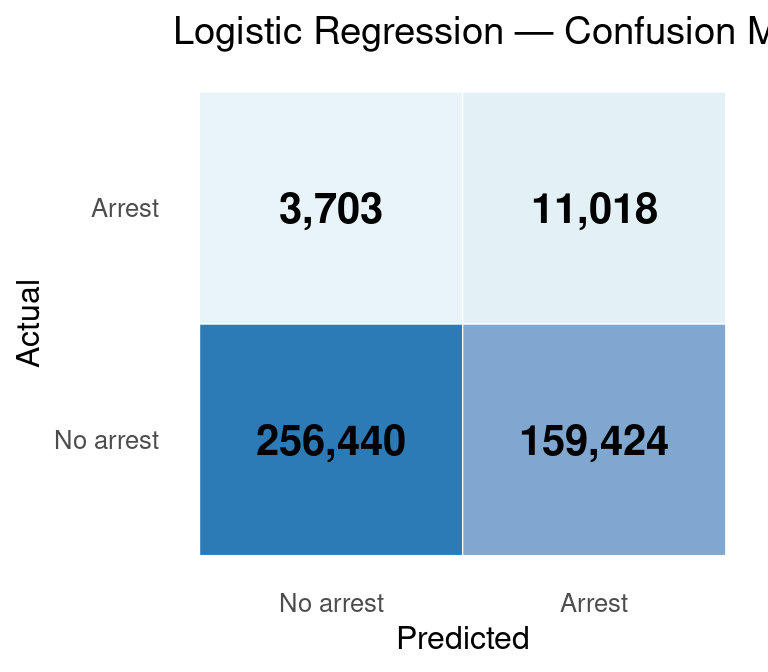

```r
plot_cm(test$arrested, class_logit, "Logistic Regression — Confusion Matrix (Youden threshold, train-selected)")
```

```r
cat(sprintf(
  "AUC: %.4f  |  Threshold (Youden, train-selected): %.4f\nSensitivity: %.3f  |  Specificity: %.3f  |  Balanced accuracy: %.3f\n",
  auc_logit, thr_logit, met_logit$sensitivity, met_logit$specificity, met_logit$balanced_acc
))
```

```
## AUC: 0.7352  |  Threshold (Youden, train-selected): 0.0297
## Sensitivity: 0.748  |  Specificity: 0.617  |  Balanced accuracy: 0.683
```

Overall, the confusion matrix confirms that the model detects most arrests but produces a large number of false alarms. Of the 14,721 actual arrests, 11,018 are correctly identified and 3,703 are missed. Among non-arrests, 256,440 are correctly rejected while 159,424 are incorrectly predicted as arrests.

Let us see the derived metrics:

| Metric | Value | Interpretation |
| --- | --- | --- |
| Accuracy | 0.621 | About 62.1% of all test observations are correctly classified, but accuracy alone is not very informative because of class imbalance |
| Sensitivity / Recall | 0.748 | About 74.8% of actual arrests are correctly detected |
| Specificity | 0.617 | About 61.7% of non-arrests are correctly identified |
| Precision | 0.065 | Only about 6.5% of predicted arrests correspond to actual arrests |
| F1 | 0.119 | Low harmonic mean of precision and recall, mainly limited by low precision |
| Balanced Accuracy | 0.683 | Moderate performance when arrests and non-arrests receive equal weight |

### 3.4.3) Performance Analysis

This was partly covered in the previous section, so here we will be focusing on the metrics that we have yet to mention.

```r
compute_metrics(test$arrested, prob_logit, thr_logit, "Logistic Regression") %>%
  kbl(
    caption   = "Logistic Regression — full evaluation metrics (test set; Youden threshold selected on training set)",
    col.names = c("Model","AUC","PR-AUC","Log-Loss","Brier",
                  "Threshold","Sensitivity","Specificity","Precision","F1","MCC","Bal. Acc.")
  ) %>%
  kable_styling(bootstrap_options = c("striped","condensed"), full_width = TRUE)
```

Logistic Regression — full evaluation metrics (test set; Youden threshold selected on training set)

| Model | AUC | PR-AUC | Log-Loss | Brier | Threshold | Sensitivity | Specificity | Precision | F1 | MCC | Bal. Acc. |
| --- | --- | --- | --- | --- | --- | --- | --- | --- | --- | --- | --- |
| Logistic Regression | 0.7352 | 0.0774 | 0.1373 | 0.0322 | 0.0297 | 0.748 | 0.617 | 0.065 | 0.119 | 0.136 | 0.683 |

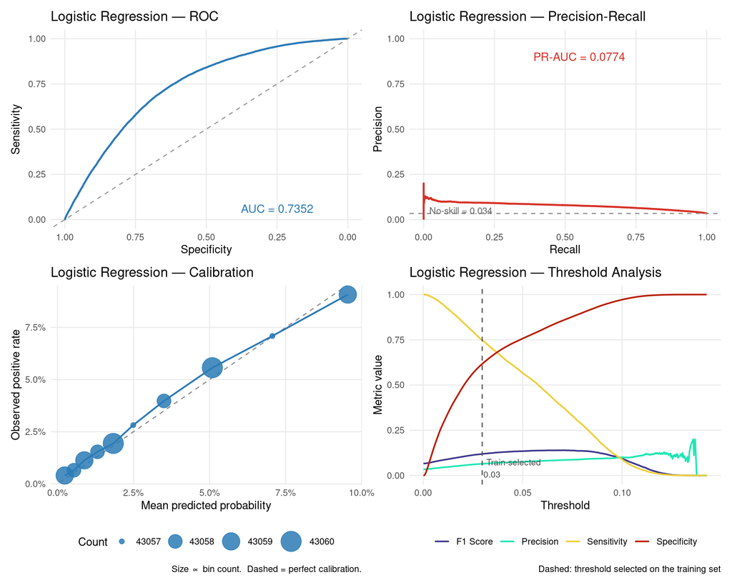

```r
eval_quad_plot(test$arrested, prob_logit, thr_logit, "Logistic Regression")
```

#### 3.4.3.1) Overall performance

| Metric | Value | Interpretation |
| --- | --- | --- |
| **AUC** | 0.7352 | Moderate discrimination between arrests and non-arrests |
| **PR-AUC** | 0.0774 | More than twice the no-skill baseline of $\approx 0.034$, although still low in absolute terms |
| **Log-Loss** | 0.1373 | Predicted probabilities improve on a prevalence-only model and contain useful predictive information |
| **Brier** | 0.0322 | Probability estimates are slightly more accurate than the prevalence-only baseline |
| Threshold | 0.0297 | Low cutoff, selected on the training set via Youden’s criterion and then applied unchanged to the test set |
| **MCC** | 0.136 | Weak positive association between predicted and observed classes |
| Balanced Accuracy | 0.683 | Moderate ability to distinguish both classes when they are weighted equally |

The main conclusion is that the Logistic Regression captures **meaningful but limited predictive signal**. Its discrimination is clearly better than chance, and it detects a relatively large proportion of arrests. However, precision remains very low because arrests represent only about **3.4% of the test set**.

#### 3.4.3.2) AUC

The test-set AUC is

$$\text{AUC} = 0.7352.$$

This means that, when randomly comparing one arrested and one non-arrested observation, the model assigns the arrested case a higher predicted probability approximately **73.5% of the time**.

This is clearly above the random-classification value of $0.5$, indicating that the predictors contain useful information about arrest risk. The discrimination can be considered **moderate**, although class separation is still imperfect and there is substantial overlap between arrests and non-arrests.

The ROC curve confirms this result: it remains clearly above the diagonal no-skill line over the full range of thresholds, although it is still some distance from the upper-left corner associated with very strong discrimination.

#### 3.4.3.3) PR-AUC

This metric is particularly important given the strong class imbalance in our outcome.

Since arrests represent only approximately **3.4% of the test observations**, ROC-AUC alone can provide an incomplete picture of performance. **Precision-Recall AUC focuses directly on the positive class**, evaluating the trade-off between retrieving arrests and maintaining precision.

Here, we obtain

$$\text{PR-AUC} = 0.0774.$$

The no-skill baseline corresponds approximately to the positive-class prevalence:

$$\text{PR-AUC}_{\text{baseline}} \approx
0.034.$$

Thus, the model achieves a PR-AUC approximately **2.3 times the prevalence baseline**.

This indicates that the model provides useful information for ranking observations in the minority class. However, the absolute PR-AUC remains low because arrests are rare. The Precision-Recall curve makes this limitation clear: precision is highest when recall is very low and progressively decreases as the model attempts to identify a larger proportion of actual arrests.

Therefore, although the model performs considerably better than random ranking, **identifying many arrests while maintaining high precision remains difficult**.

#### 3.4.3.4) Log-Loss

> Log-loss evaluates the **quality of the predicted probabilities**, rather than simply whether the final classification is correct.

It also accounts for the confidence of the predictions, heavily penalizing cases in which the model assigns a very confident probability to the wrong outcome.

In our case:

$$\text{Log-Loss} = 0.1373.$$

For comparison, a prevalence-only model predicting approximately $p=0.034$ for every observation would have a log-loss of approximately

$$\text{Log-Loss}_{\text{baseline}}
\approx 0.149.$$

The fitted Logistic Regression therefore improves on the prevalence-only baseline.

This suggests that the estimated probabilities contain **genuine predictive information** beyond simply knowing the overall arrest rate. The improvement is nevertheless moderate, which is consistent with the model’s overall predictive performance.

#### 3.4.3.5) Brier Score

The Brier score evaluates how close the predicted probabilities are to the observed binary outcomes.

> Formally, the Brier score is the mean squared difference between the predicted probabilities and the observed outcomes, with lower values indicating better probability predictions.

The model obtains

$$\text{Brier} = 0.0322.$$

A prevalence-only model with an arrest probability of approximately $0.034$ would obtain a Brier score of approximately

$$\text{Brier}_{\text{baseline}} \approx
0.0330.$$

The improvement is therefore **small but positive**.

The calibration plot provides additional information. Most of the binned observations lie relatively close to the dashed perfect-calibration line, indicating that the model’s predicted probabilities are **broadly consistent with the observed arrest frequencies**.

There are some deviations, particularly across the lower probability bins, but no strong systematic departure from the diagonal is visible. Overall, calibration appears reasonably good within the relatively narrow probability range produced by the model.

#### 3.4.3.6) MCC

The **Matthews Correlation Coefficient (MCC)** is particularly useful for imbalanced classification because it incorporates all four components of the confusion matrix:

$$MCC =
\frac{TP\cdot TN-FP\cdot FN}
{\sqrt{(TP+FP)(TP+FN)(TN+FP)(TN+FN)}}
\in [-1,1].$$

Where:

- $1$ = perfect prediction
- $0$ = no association between predictions and observations
- $-1$ = completely incorrect prediction

$$MCC = 0.136.$$

This represents a **weak but positive association** between the predicted and observed classes.

Therefore, the classifier performs better than random classification, but the relatively low MCC confirms that its threshold-based predictions remain limited. This is largely consistent with the very low precision: although the model captures many actual arrests, it also generates a large number of false positives.

#### 3.4.3.7) Thresholds

Using Youden’s criterion, the selected classification threshold is

$$t^* = 0.0297.$$

This threshold is selected once by maximising Youden’s $J$ on the training-set ROC curve, then frozen and applied unchanged to the test set, so no test-set information is used in choosing the cutoff.

This is much lower than the conventional $0.5$ cutoff, which reflects the rarity of arrests (about **3.4% of observations**). The low threshold prioritizes detection of the positive class, whereas using $0.5$ would classify very few cases as arrests and would consequently result in extremely poor sensitivity.

resulting in

$$\text{Balanced
Accuracy}=0.683.$$

Thus, approximately **74.8% of actual arrests are detected**, while approximately **61.7% of actual non-arrests are correctly classified as non-arrests**. This sensitivity comes at the cost of many false-positive arrest predictions.

The threshold-analysis plot illustrates the expected trade-off clearly. At very low thresholds, sensitivity is close to 1 but specificity is poor because many observations are classified as arrests. As the threshold increases, **specificity increases while sensitivity decreases**.

Youden’s criterion selects approximately $0.03$, close to the point where a relatively favorable balance between these two measures is obtained.

Precision at this threshold remains very low:

$$\text{Precision}=0.065.$$

Therefore, only about **6.5% of observations classified as arrests are actually arrests**. This is a direct consequence of combining a rare positive class with a threshold designed to maintain relatively high sensitivity.

The F1 score is consequently also low:

$$F1 = 0.119.$$

Overall, the chosen threshold favors **detecting a large proportion of arrests at the cost of a substantial number of false alarms**.

#### 3.4.3.8) Final Remarks

Let us put the metrics together:

- **Discrimination**, $\text{AUC} \approx 0.735$: the model ranks arrests above non-arrests substantially better than chance, although discrimination remains moderate.
- **Rare-class performance**, $\text{PR-AUC} \approx 0.077$: performance is approximately **2.3 times the no-skill baseline of** $\approx 0.034$, but precision remains low in absolute terms.
- **Probability predictions**, $\text{Brier} \approx 0.032$ and $\text{LogLoss} \approx 0.137$: both improve on prevalence-only predictions, while the calibration plot suggests broadly reasonable agreement between predicted and observed probabilities.
- **Classification**, $\text{MCC} \approx 0.136$: threshold-based predictions show a weak but genuine positive association with the observed outcome.
- **Class balance**, $\text{ACC}_{\text{Balanced}} \approx 0.683$: the model achieves moderate performance when sensitivity and specificity are given equal importance.
- **Sensitivity**, $0.748$: the model detects about three quarters of actual arrests, although this comes at the cost of low precision.

Now for the final conclusions:

- The Logistic Regression captures **meaningful predictive structure** in the arrest outcome, with noticeably better discrimination than random classification.
- The ROC curve confirms a moderate ability to distinguish arrests from non-arrests, while the PR curve shows that the severe class imbalance makes positive-class prediction considerably more difficult.
- The predicted probabilities are **reasonably calibrated overall**, and both Log-Loss and Brier score improve on the corresponding prevalence-only baselines.
- The selected Youden threshold of $0.0297$ substantially increases the ability to detect arrests compared with a conventional $0.5$ cutoff.
- However, the resulting **precision of only 6.5%** means that most predicted arrests are false positives.
- Therefore, the selected threshold should be interpreted as a compromise between **sensitivity and specificity**, rather than as a cutoff capable of producing highly reliable individual classifications.
- Overall, the Logistic Regression provides a useful **interpretable baseline and risk-ranking model**, but its predictions are not sufficiently precise to treat individual arrest classifications as highly reliable.

## 3.5) Diagnostics

### 3.5.1) Multicollinearity (VIF)

Variance Inflation Factors measure how much each predictor’s variance is inflated by collinearity with the others.

Because `mod_logit_best` contains several multi-level categorical predictors (generating multiple coefficients), multicollinearity is computed using the **Generalised Variance Inflation Factor (GVIF)** rather than the standard VIF.

The adjusted quantity $\text{GVIF}^{1/(2\,\text{df})}$ accounts for the number of degrees of freedom associated with each predictor and makes the values comparable across terms. In this sense, it can be interpreted on approximately the same scale as $\sqrt{VIF}$.

**How do we interpret this?**

- Values close to 1 indicate that the corresponding predictor has little linear dependence with the remaining predictors;
- Instead, larger values indicate potential multicollinearity.

```r
vif_tbl <- as.data.frame(car::vif(mod_logit_best))
vif_tbl$predictor <- rownames(vif_tbl)
rownames(vif_tbl) <- NULL

# Rename columns robustly (vif() returns 3-col df for factors)
if (ncol(vif_tbl) == 4) {
  names(vif_tbl)[1:3] <- c("GVIF", "Df", "GVIF_adj")
} else {
  names(vif_tbl)[1] <- "GVIF"
  vif_tbl$Df <- 1
  vif_tbl$GVIF_adj <- sqrt(vif_tbl$GVIF)
}

vif_tbl %>%
  arrange(desc(GVIF_adj)) %>%
  mutate(flag = ifelse(GVIF_adj > sqrt(5), "⚠ >sqrt5", "OK")) %>%
  kbl(
    digits = 3,
    caption = "Logistic regression — Generalised VIF (GVIF^(1/2df) comparable to sqrt(VIF))"
  ) %>%
  kable_styling(bootstrap_options = c("striped", "condensed"), full_width = FALSE)
```

Logistic regression — Generalised VIF (GVIF^(1/2df) comparable to sqrt(VIF))

| GVIF | Df | GVIF_adj | predictor | flag |
| --- | --- | --- | --- | --- |
| 1.266 | 5 | 1.024 | ethnicity | OK |
| 1.070 | 2 | 1.017 | sex | OK |
| 1.208 | 7 | 1.014 | boro | OK |
| 1.012 | 2 | 1.003 | year | OK |
| 1.037 | 6 | 1.003 | weekday | OK |
| 1.036 | 7 | 1.003 | age_bracket | OK |
| 1.097 | 23 | 1.002 | hour | OK |
| 1.019 | 11 | 1.001 | month | OK |

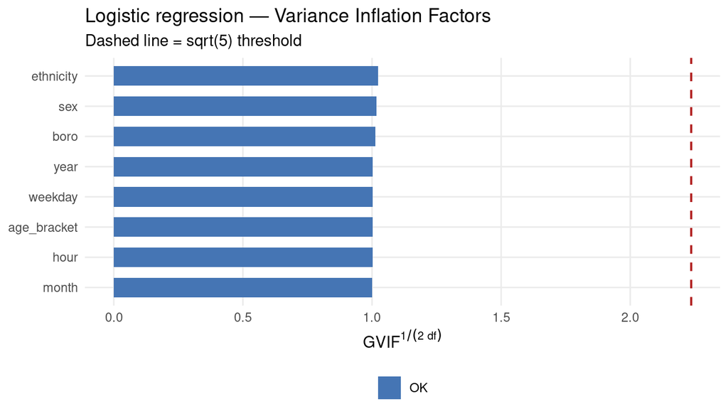

```r
ggplot(
  vif_tbl,
  aes(
    x = reorder(predictor, GVIF_adj),
    y = GVIF_adj,
    fill = GVIF_adj > sqrt(5)
  )
) +
  geom_col(width = 0.65) +
  geom_hline(
    yintercept = sqrt(5), linetype = "dashed",
    colour = "firebrick", linewidth = 0.7
  ) +
  scale_fill_manual(
    values = c("FALSE" = "#4575b4", "TRUE" = "#d73027"),
    labels = c("OK", ">5 threshold"), name = NULL
  ) +
  coord_flip() +
  labs(
    x = NULL,
    y = expression(GVIF^{1/(2~df)}),
    title = "Logistic regression — Variance Inflation Factors",
    subtitle = "Dashed line = sqrt(5) threshold"
  ) +
  theme_minimal(base_size = 11) +
  theme(legend.position = "bottom", panel.grid.minor = element_blank())
```

Therefore, there is **no evidence of problematic multicollinearity among the predictors**. This is particularly relevant for predictors such as `hour`, `month`, and `boro`, which contain many factor levels but still show adjusted GVIF values essentially equal to 1.

### 3.5.2) Influential Observations

Influence diagnostics assess whether individual observations have an unusually large effect on the fitted logistic regression model.

Here we consider **Cook’s distance** which measures how much the fitted model would change if a given observation were removed.

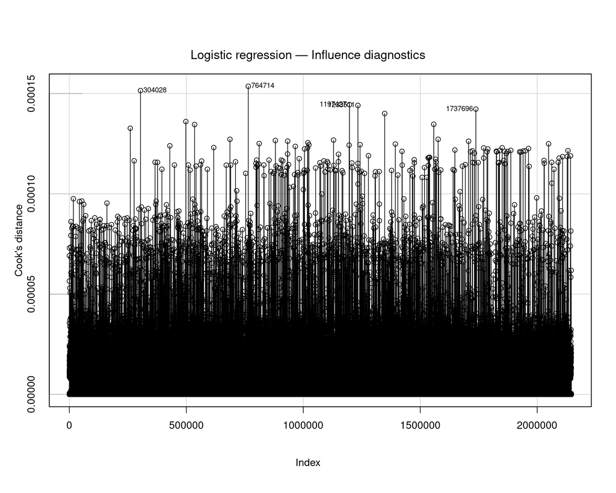

```r
car::influenceIndexPlot(
  mod_logit_best,
  vars  = c("Cook"),
  id    = list(n = 5, cex = 0.7),
  main  = "Logistic regression — Influence diagnostics"
)
```

In the plot, the vast majority of observations have Cook’s distances very close to zero. This shows that individual obs. tend to have little influence on the fitted model. A small batch of observations show larger values, but none of them appears to dominate the model.

Overall, the Cook’s distance diagnostic suggests that the logistic regression is **not being driven by a small number of highly influential observations**.